# ch3_MDP

```python
from IPython.display import Image
```

### Intro

- MDP and agent interact in a sequence that can be charactersied

$S_0,A_0,R_1,S_1,A_1,R_2,S_2,A_2,R_3$

$\mathcal{S}$ - states, $\mathcal{A}$ - actions, $\mathcal{R}$ - rewards.

$R_t$ and $S_t$ have well defined discrete probability distributions that are dependant only on the preceeding state and action. Hence $$P(s',r|s,a) = P(S_t = s', R_t = r | S_{t-1} = s, A_{t-1} = a)$$

for all $s', s \in \mathcal{S}, r \in \mathcal{R}$ and $a \in \mathcal{A}(s)$.

$P: \mathcal{S} \times \mathcal{R} \times \mathcal{S} \times \mathcal{A} \rightarrow [0,1]$

$$\sum_{s' \in \mathcal{S}} \sum_{r \in \mathcal{R}} P(s',r|s,a) = 1$$

for all $s \in \mathcal{S}, a \in \mathcal{A}(s)$.

- $P$ completely characterizes the environments dynamics.

### Computing other things from P

- $P(s'|s,a) = \sum_{r \in \mathcal{R}} P(s',r|s,a)$
- Expected reward $r(s,a) = \mathbb{E}(R_t|S_{t-1}=s,A_{t-1} = a) = \sum_{r \in \mathcal{R}} r \sum_{s' \in \mathcal{S}} P(s',r|s,a)$
- Expected reward for state action state pair $$r(s,a,s') = \mathbb{E}(R_t | S_{t-1} = s, A_{t-1} = a, S_{t} = s') = \sum_{r \in \mathcal{R}} r \frac{P(s',r|s,a)}{P(s'|s,a)} $$

## Example: Recycling Robot

- Robot makes high leve decisions about how to sesarch for cans.
- Decisions about how to search for cans based on charge level of battery.
- Simple only two levels of charge $S = \{\mathrm{high}, \mathrm{low}\}$
- Actions $A = \{\mathrm{search}, \mathrm{wait} \}$
- Action sets or state action pairs are $\mathcal{A}(\mathrm{low}) = \{\mathrm{search,wait,recharge}\}$ and $\mathcal{A}(\mathrm{high}) = \{\mathrm{search}, \mathrm{wait} \}$.

### Environment dynamics

- Rewards become positive when robot secures an empty can. Or large negative when battery runs all the way down.
- To find cans you need to search for them but possibility of becoming depleted exists.
- If energy is high the a period of active search can always be completed without risk of depleting the battery.
- state = high -> action = search -> state' = high with $P = \alpha$
- state = high -> action = search -> state' = low with $P = 1-\alpha$
- state = low -> action = search -> state' = low with $P = \beta$
- state = low -> action = search -> state' = high with $P = 1-\beta$.
- All other state transitions when action = weight are done with binary probabilities.
- Every time a can is collected the robot gets a unit reward. A reward of -3 results whenever the robot needs to be rescued. Let $r_{\mathrm{search}}$ and $r_{\mathrm{wait}}$ denote the expected rewards during searching and waiting with $r_{\mathrm{search}}> r_{\mathrm{wait}}$.

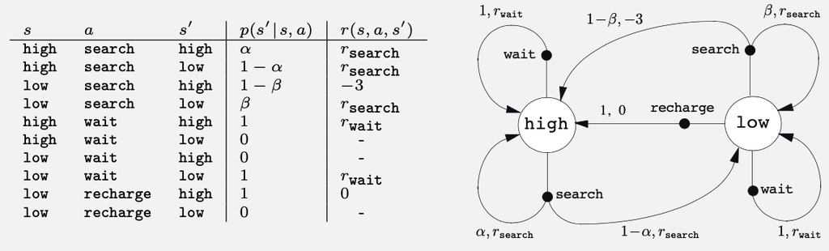

```python
Image("../figs/robot_cans.png")
```

# Goals and Rewards

- $R_t$ is the reward at time step $t$.
- Informally the agent wants to maximize the total amount of reward it recieves, so this is NOT necessarily maximising immediate reward, but the cumulative reward in the long run.
- What exactly to do we want to maximize? One example is $G_t = R_{t+1}+R_{t+2}+\ldots+R_T$, this works well for cases where interactions can be broken into episodes (natural subsequences of agent-environment interaction). Each episode has an end state and the following episode restarts. The termination time of an epsiode $T$ is a random variable.
- Other cases the agent environment interaction is continous.
- In this case to make the mathematics tractable we work with discounted return

$$G_t = R_{t+1} + \gamma R_{t+2} + \ldots + \gamma^{k} R_{t+k+1} + \ldots $$

where $0 \leq \gamma \leq 1$ is the discount factor.

- If we are myopic $\gamma=0$ and we look only to maximize immediate reward we can learn how to choose $A_{t}$ to maximize only $R_{t+1}$.
- As $\gamma$ approaches $1$ the agent becomes more far sighted.
- Note $G_t = R_{t+1} + \gamma G_{t+1}$.

### Unified view of continous and episodic tasks

- We can unify the view of episodic and continous tasks by allowing for the introduction of a special termination node that transitions only to itself and generates 0 returns.
- This allows us to generalise sums to include $\gamma = 1$ or $T = \infty$ but not both

## Policies and Value functions

- Value functions - functions of states or of state-action pairs that estimate how good it is for the agent to be in a given state.
- Notion of how good is defined in terms of future rewards. E.g. do you act greedy and maximise your immediate reward in picking next action? Or do you think longer ahead?
- Formally a policy $\pi$ maps a state $s \in S$ to a probability of selecting each action given the state $\pi(a|s)$. Hence $\pi(a|s)$ is the probabililty distribution $a \in \mathcal{A}(s)$.
- We specify how the agents policy is changed as a result of its in experience in RL methods.

### Exercise 3.11

question: If the current state is $S_t$ and actions are selected according to stochastic policy $\pi$ then what is $\mathbb{E}(R_{t+1})$ in terms of $\pi$ and the four-arguement function $p$?

solution:

By definition $\mathbb{E}(R_{t+1}|S_{t}=s) = \sum_{r} r*P(R_{t+1}=r | S_{t} = s)$ but we want to express this interms of the four state probability function $P(S_{t+1},R_{t+1}|S_{t},A_{t})$. We use marginalisation

$$P(R_{t+1} = r | S_{t} = s) = \sum_{S_{t+1}} P(R_{t+1} = r, S_{t+1} = s' | S_{t} = s)$$

and

$$P(R_{t+1} = r, S_{t+1} = s'| S_{t} = s) = \sum_{a \in \mathcal{A}(s)} P(R_{t+1} = r, S_{t+1} = s', A_{t} = a | S_{t} = s) = \sum_{a \in \mathcal{A}(s)} P(R_{t+1} = r, S_{t+1} = s'| S_{t} = s, A_{t}=a)\pi(A_{t}=a|S_{t}=s)$$

Hence

$$ \mathbb{E}(R_{t+1}|S_{t}=s) = \sum_{r} r\sum_{S_{t+1}} \sum_{a \in \mathcal{A}(s)} P(R_{t+1} = r, S_{t+1} = s'| S_{t} = s, A_{t}=a)\pi(A_{t}=a|S_{t}=s) $$

### End of Exercise 3.11

### Value function

- $\textbf{Value function}$: Of a state $s$ under a policy $\pi$, denoted $v_{\pi}(s)$, is the expected return when starting in $s$ and following $\pi$ thereafter. Formally

$$v_{\pi}(s) = \mathbb{E}_{\pi}[G_{t}|S_{t}=s] = \mathbb{E}_{\pi}[\sum_{k=0}^{\infty} \gamma^{k} R_{t+k+1} |S_{t}=s] $$

for all $s \in \mathcal{S}$.

### State - action value function

- Similarly we can define the value of taking action $a$ in state $s$ under a policy $\pi$ denoted $q_{\pi}(s,a)$ as the expected return starting from $s$, taking the action $a$, and thereafter following policy $\pi$.

$$ q_{\pi}(s,a) = \mathbb{E}_{\pi}[G_t|S_{t}=s,A_{t}=a] = \mathbb{E}_{\pi}[\sum_{k=0}^{\infty} \gamma^{k} R_{t+k+1} |S_{t}=s, A_{t}=a] $$

for all $s \in \mathcal{S}$

### Exercise 3.12

question: Give an equation for $v_{\pi}$ in terms of $q_{\pi}$ and $\pi$.

$$ v_{\pi}(s) = \sum_{g} gP(G_{t}=g|S_{t}=s) $$

Now $P(G_{t}=g|S_{t}=s) = \sum_{a \in \mathcal{A}(s)} P(G_{t}=g, A_{t}=a|S_{t}=s) = \sum_{a \in \mathcal{A}(s)} P(G_{t}=g|S_{t}=s,A_{t}=a)\pi(a|S_{t}=s)$

Hence

$$ v_{\pi}(s) = \sum_{a} \sum_{g} gP(G_{t}=g|S_{t}=s,A_{t}=a)\pi(a|S_{t}=s) $$

And so

$$ v_{\pi}(s) = \sum_{a}\pi(a|S_{t}=s) \sum_{g} gP(G_{t}=g|S_{t}=s,A_{t}=a)$$

and thus we get

$$ v_{\pi}(s) = \sum_{a}\pi(a|S_{t}=s) q_{\pi}(S_{t}=s,A_{t} = a). $$

With the last line following from the definition $q_{\pi}(S_{t}=s,A_{t}=a) = \mathbb{E}(G_{t}|S_{t}=s,A_{t}=a) = \sum_{g} gP(G_{t}=g|S_{t}=s,A_{t}=a)$.

### End of Exercise 3.12

### Exercise 3.13

question: Given an equation for $q_{\pi}$ in terms of $v_{\pi}$ and the four-arguement $p$.

solution: We will use the fact that using iterated expectations $$\mathbb{E}(G_{t+1}|S_{t}=s) = \mathbb{E}_{\pi} [\mathbb{E}_{\pi}[G_{t+1}|S_{t+1}=s']|S_{t}=s] = \mathbb{E}_{\pi}[v_{\pi}(S_{t+1})|S_{t}=s]$$

Hence

$$q_{\pi}(s,a) = \mathbb{E}_{\pi}[G_t|S_t=s,A_t=a] = \mathbb{E}_{\pi}[R_{t+1}+\gamma G_{t+1}|S_t=s,A_t=a] = \mathbb{E}_{\pi}[R_{t+1}|S_{t}=s,A_{t}=a]+\mathbb{E}_{\pi}[\gamma G_{t+1}|S_t=s,A_t=a] $$

Now we can calculate each part remembering we want to express it in the form of $S_t,A_t,R_t,S_{t+1}$ to get

1. $\mathbb{E}_{\pi}[R_{t+1}|S_t=s,A_t=a] = \sum_{r} r P(R_{t+1}=r|S_t=s,A_t=a) = \sum_{r} \sum_{s'} rP(R_{t+1}=r,S_{t+1}=s'|S_{t}=s',A_{t}=a)$
2. $\mathbb{E}_{\pi}[\gamma G_{t+1}|S_t=s,A_t=a] = \gamma \mathbb{E}_{\pi}[\mathbb{E}_{\pi}[G_{t+1}|S_{t+1}=s']|S_{t}=s,A_{t}=a] = \gamma\mathbb{E}_{\pi}[v_{\pi}(S_{t+1})|S_{t}=s,A_t=a]$. Now $$\mathbb{E}_{\pi}[v_{\pi}(S_{t+1})|S_{t}=s,A_{t}=a] = $$ $$\sum_{s'} v_{\pi}(S_{t+1}=s')P(S_{t+1}=s'|S_{t}=s,A_{t}=a) = \sum_{r}\sum_{s'} v_{\pi}(S_{t+1}=s')P(R_{t+1}=r,S_{t+1}=s'|S_{t}=s,A_{t}=a)$$
- Hence we get $$ q_{\pi}(s,a) = \sum_{r}\sum_{s'} (r+\gamma v_{\pi}(S_{t+1}=s'))P(R_{t+1}=r,S_{t+1}=s'|S_{t}=s,A_{t}=a)$$

### End of Exercise 3.13

- For any policy $\pi$ and any state $s$, the following consistency condition holds between the value of $s$ and the value of its possible successor states. Using the previous two results we find that

$$v_{\pi}(s) = \sum_{a} \pi(a|s) \sum_{r}\sum_{s'} (r+\gamma v_{\pi}(S_{t+1}=s'))P(R_{t+1}=r,S_{t+1}=s'|S_{t}=s,A_{t}=a)$$

- The equation is referred to as the Bellman equation for $v_{\pi}$. It expresses the relationship between the value of a state and the values of its successor states.
- The Bellman equation (3.14) averages over all the possibilities, weighting each by its probability of occurring. It states that the value of the start state must equal the (discounted) value of the expected next state, plus the reward expected along the way.
- The diagram can also be captured in a back up diagram shown below.
- The value function $v_{\pi}$ is the unique solution to its Bellman equation.

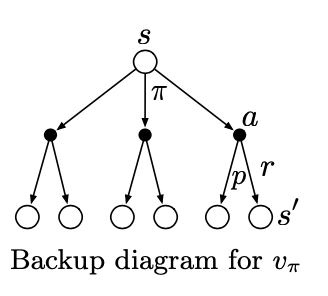

```python
Image("../figs/backup_diagram.png")
```

- So at a given state $S$ at the white node we use our policy $\pi$ to pick an action which takes us to one of the black nodes which then gives us a reward and a new state $S'$ given at the white node.

# Example: Gridworld

### Exercise 3.17

question: What is the Bellman equation for action values that is for $q_{\pi}$?

solution: We know that $$ q_{\pi}(s,a) = \sum_{r}\sum_{s'} (r+\gamma v_{\pi}(S_{t+1}=s'))P(R_{t+1}=r,S_{t+1}=s'|S_{t}=s,A_{t}=a)$$ from exericse 3.13. We know from exercise 3.12 that $v_{\pi}(s') = \sum_{a'}\pi(a'|S_{t+1}=s') q_{\pi}(S_{t+1}=s',A_{t+1} = a').$$

Hence $$q_{\pi}(s,a) = \sum_{r}\sum_{s'} (r+\gamma \sum_{a'}\pi(a'|S_{t+1}=s') q_{\pi}(S_{t+1}=s',A_{t+1} = a') )P(R_{t+1}=r,S_{t+1}=s'|S_{t}=s,A_{t}=a)$$

### End of Exercise 3.17

### Exercise 3.18

question: Give the equation corresponding to this intuition and diagram for the value at the root node, $v_{\pi}(s)$, in terms of the value at the expected leaf node, $q_{\pi}(s, a)$, given $S_t = s$. Then give a second equation in which the expected value is written out explicitly in terms of $\pi(a|s)$ such that no expected value notation appears in the equation.

solution: We know that $$v_{\pi}(s) = \mathbb{E}_{\pi}[G_{t}|S_{t}=s] = \mathbb{E}_{\pi}[G_{t}|S_{t}=s,A_{t}=a]P(A_{t}=a|S_{t}=s) = q_{\pi}(s,a)\pi(a|s) $$

### End of Exercise 3.18

### Exercise 3.19

question: Give the equation corresponding to this intuition and diagram for the action value, $q_\pi(s,a)$, in terms of the expected next reward, $R_{t+1}$, and the expected next state value, $v_{\pi}(S_{t+1})$, given that $S_t =s$ and $A_t =a$. This equation should include an expectation but not one conditioned on following the policy. Then give a second equation, writing out the expected value explicitly in terms of $p(s_0,r|s,a)$ defined by (3.2), such that no expected value notation appears in the equation.

solution: We have already shown in Exercise 3.13 that $$ q_{\pi}(s,a) = \sum_{r}\sum_{s'} (r+\gamma v_{\pi}(S_{t+1}=s'))P(R_{t+1}=r,S_{t+1}=s'|S_{t}=s,A_{t}=a).$$

Hence $$q_{\pi}(s,a) = \mathbb{E}(r+\gamma v_{\pi}(S_{t+1}=s')|S_{t}=s,A_{t}=a)$$

### End of Exercise 3.19

# Optimal Policies and Optimal Value Functions

- Solve the reinfocement learning task by finding a policy that achieves a lot of reward over the long run.
- For finte MDPs value functions $v_{\pi}$ define a partial ordering over the policies $\pi$.
- A policy $\pi$ is defined to be better than or equal to a policy $\pi'$ if its expected return is greater than or equal to that of $\pi$' for all states. Equivalently $\pi \geq \pi'$ if and only if $v_{\pi}(s) \geq v_{\pi'}(s)$ for all $s \in \mathcal{S}$.
- There is always at least one optimal policy. This policy is better than all other policies. Denote all the optimal policies by $\pi_{*}$.

### Properties of optimal policies

- All optimal policies share the same state-value function, called the optimal state-value function denoted $$v_{*}(s) = \mathrm{max}_{\pi} v_{\pi}(s)$$ for all $s \in \mathcal{S}$. So the optimal value function for the optimal policy satisfies that the value of each state is maximised over all policies $\pi$.
- Optimal policies also share the same optimal action-value function, denoted $q_{*}$ and defined as $q_{*}(s,a) = \mathrm{max}_{\pi} q_{\pi}(s,a)$ for all $s \in \mathcal{S}, a \in \mathcal{A}(s)$. For the state-action pair $(s,a)$ this function gives the expected return for taking action a in state $s$ and thereafter following an optimal policy.

Re-writing $q_{*}$ interms of $v_{*}$ we get $$q_{*}(s,a) = \mathbb{E}(R_{t+1}+\gamma v_{*}(S_{t+1})|S_{t}=s,A_{t}=a].$$